# Mixed ANOVA + Pairwise Comparison

5/7/2021

# Description

**Source of motivation: [Mixed ANOVA in R](https://www.datanovia.com/en/lessons/mixed-anova-in-r)** **Adapted from Ruslan Klymentiev RAnovas_main.R for the same project**

## Assumptions Check

**Outliers**. Values above `Q3 + 1.5xIQR` or below `Q1 - 1.5xIQR` are considered as outliers. Values above `Q3 + 3xIQR` or below `Q1 - 3xIQR` are considered as extreme points (or extreme outliers). Observations that are considered as extreme points are marked red.

**Normality Assumptions**. Plot shows Q-Q plot for subsets of data. If points lie on the line, we can assume that data is fairly symmetrical (and that’s what we want).

**Homogeneity of Variance Assumption**. Performed using [Levene’s test](https://en.wikipedia.org/wiki/Levene%27s_test).

$H_0$: the groups have equal population variances $H_A$: the groups don’t have equal population variances Observations with p-value < 0.05 are marked red, since they may violate the ANOVA results.

## Mixed ANOVA

“*In statistics, a mixed-design analysis of variance model, also known as a split-plot ANOVA, is used to test for differences between two or more independent groups whilst subjecting participants to repeated measures.*” ([Wikipedia](https://en.wikipedia.org/wiki/Mixed-design_analysis_of_variance))

within subjects group (with repeated measures): `Measurement` between subjects group: `Group`

## Post-hoc Tests

**Significant two-way interaction**. Can be used if an interaction term in Mixed ANOVA results showed significance. In other words, impact of `Group` on the outcome variable (`VectorStrength`) depends on the `Measurement` (and vice versa)

**Effect of `Group` at each `Measurement`**. Shows the **simple main effect** of the `Group`

**Pairwise comparisons between `Group`**. Performs [Welch’s t-tests](https://en.wikipedia.org/wiki/Welch%27s_t-test) (for unequal variances) for comparing `Group` for each `Measurement`

**Effect of `Measurement` at each level of `Group`**. Shows the **simple main effect** of the **`Measurement`**

**Pairwise comparisons between `Measurement`**. Performs **paired** two-sample t-test for comparing `Measurement` for each `Group`.

**Non-significant two-way interaction**. Shows the **main effect** for `Group` and `Measurement`. Used if there was non-significant two-way interaction.

For each table observations with adjusted p-value (using Bonferroni correction) which is less then 0.05 are marked green.

```r
library(tidyverse)
library(ggpubr)
library(rstatix)
library(knitr)
library(kableExtra)
```

```r
raw_data <- read_csv("D:/DynamicCSDjl/Data/VSoutput/CL_10_VectorStrength_Stats.csv")
data_type <- "CL"

layers <- unique(raw_data$Layer)
stimfreq <- 5
metrics <- c("VectorStrenght")

red_color <- "#ffb3b3"
green_color <- "#d6f5d6"

# values for testing
freq <- 5
layer <- "All"
metric <- "VectorStrenght"
```

# Results

```r
for (layer in layers){
  # for (layer in c("All", "I_II")){
  cat("###", layer, " Layer {.tabset .tabset-fade .tabset-pills}\n")

  model_data <- raw_data %>%
    filter(
      Layer == layer)

  model_data <- model_data %>%
    select(Group, Animal, Measurement, VectorStrenght)

  if(grepl("CL", data_type)) {
    model_data <- model_data %>%
      convert_as_factor(Group, Animal, Measurement) %>%
      reorder_levels(
        Measurement,
        order = c("preCL_1", "CL_1", "CL_2", "CL_3", "CL_4"))
  } else {
    model_data <- model_data %>%
      filter(Measurement != "AM_5") %>%
      reorder_levels(
        Measurement,
        order = c("preAM_1", "AM_1", "AM_2", "AM_3", "AM_4"))
  }

  cat("####", metric, "{.tabset .tabset-fade .tabset-pills}\n")

  cat("##### Assumptions Check\n")

  cat("<b>===OUTLIERS===</b>\n\n")

  df <- model_data %>%
    group_by(Measurement, Group) %>%
    identify_outliers(eval(metric))

  if(nrow(df) > 0){
    df %>%
      kable(escape = F, digits = 6) %>%
      kable_classic_2(full_width = F) %>%
      kable_styling() %>%
      row_spec(
        which(df$is.extreme == TRUE), bold = T,
        background = red_color) %>%
      print()
  } else{
    cat("\n\nNo outliers were detected.\n\n")
  }

  cat("\n\n<b>===NORMALITY ASSUMPTION===</b>\n\n")

  p <- ggqqplot(model_data, metric, ggtheme = theme_bw()) +
    facet_grid(Measurement ~ Group)
  plot(p)

  cat("\n\n<b>===HOMOGENEITY OF VARIANCE ASSUMPTION===</b>\n\n")

  df <- model_data %>%
    group_by(Measurement) %>%
    levene_test(formula = as.formula(paste0(metric, "~ Group")))

  df %>%
    kable(escape = F, digits = 3) %>%
    kable_classic_2(full_width = F) %>%
    kable_styling() %>%
    row_spec(
      which(df$p <= 0.05), bold = T,
      background = red_color) %>%
    print()

  cat('\n\n')

  cat("##### Mixed ANOVA\n")

  # Two-way mixed ANOVA test
  res.aov <- anova_test(
    data = model_data, dv = eval(metric), wid = Animal,
    between = Group, within = Measurement)

  df <- get_anova_table(res.aov) %>%
    data.frame()

  df %>%
    kable(escape = F) %>%
    kable_classic_2(full_width = F) %>%
    kable_styling() %>%
    row_spec(
      which(df$p <= 0.05), bold = T,
      background = green_color) %>%
    print()

  cat('\n\n')

  cat("##### Post-hoc Tests\n")

  cat("\n\n<b>===SIGNIFICANT TWO-WAY INTERACTION===</b>\n\n")

  cat("\n\n\n<b>=EFFECT OF GROUP AT EACH MEASUREMENT=</b>\n\n")

  one.way <- model_data %>%
    group_by(Measurement) %>%
    anova_test(dv = eval(metric), wid = Animal, between = Group) %>%
    get_anova_table() %>%
    adjust_pvalue(method = "bonferroni")

  df <- one.way %>%
    data.frame() %>%
    select(-F)
  df %>%
    kable(escape = F) %>%
    kable_classic_2(full_width = F) %>%
    kable_styling() %>%
    row_spec(
      which(df$p.adj <= 0.05), bold = T,
      background = green_color) %>%
    print()

  cat("\n\n\n<b>=PAIRWISE COMPARISONS BETWEEN GROUP LEVELS=</b>\n\n")

  pwc <- model_data %>%
    group_by(Measurement) %>%
    pairwise_t_test(
      as.formula(paste0(metric, "~ Group")),
      p.adjust.method = "bonferroni",
      pool.sd = FALSE,
      var.equal = FALSE)

  eff_size <- model_data %>%
    group_by(Measurement) %>%
    cohens_d(
      as.formula(paste0(metric, "~ Group")),
      var.equal = FALSE)

  df <- pwc %>%
    left_join(eff_size) %>%
    data.frame()

  df %>%
    kable(escape = F, digits = 3) %>%
    kable_classic_2(full_width = F) %>%
    kable_styling() %>%
    row_spec(
      which(df$p.adj <= 0.05), bold = T,
      background = green_color) %>%
    print()

  cat("\n\n\n<b>=EFFECT OF MEASUREMENT AT EACH LEVEL OF GROUP=</b>\n\n")

  one.way2 <- model_data %>%
    group_by(Group) %>%
    anova_test(dv = eval(metric), wid = Animal, within = Measurement) %>%
    get_anova_table() %>%
    adjust_pvalue(method = "bonferroni")

  df <- one.way2 %>%
    data.frame()
  df %>%
    kable(escape = F) %>%
    kable_classic_2(full_width = F) %>%
    kable_styling() %>%
    row_spec(
      which(df$p.adj <= 0.05), bold = T,
      background = green_color) %>%
    print()

  cat("\n\n\n<b>=PAIRWISE COMPARISONS BETWEEN MEASUREMENTS AT EACH GROUP LEVELS=</b>\n\n")

  exclude_animals <- model_data %>%
    group_by(Animal) %>%
    summarise(n = n_distinct(Measurement)) %>%
    filter(n < 5) %>%
    pull(Animal)

  pwc2 <- model_data %>%
    filter(!(Animal %in% exclude_animals)) %>%
    group_by(Group) %>%
    pairwise_t_test(
      as.formula(paste0(metric, "~ Measurement")),
      paired = TRUE,
      pool.sd = FALSE,
      var.equal = FALSE,
      p.adjust.method = "bonferroni"
    )

  eff_size2 <- model_data %>%
    filter(!(Animal %in% exclude_animals)) %>%
    group_by(Group) %>%
    cohens_d(
      as.formula(paste0(metric, "~ Measurement")),
      paired = TRUE,
      var.equal = FALSE)

  df <- pwc2 %>%
    left_join(eff_size2) %>%
    data.frame()
  df %>%
    kable(escape = F, digits = 3) %>%
    kable_classic_2(full_width = F) %>%
    kable_styling() %>%
    row_spec(
      which(df$p.adj <= 0.05), bold = T,
      background = green_color) %>%
    print()

  cat("\n\n\n<b>===NON-SIGNIFICANT TWO-WAY INTERACTION===</b>\n\n")
  cat("\n\n\n<b>=MAIN EFFECT OF MEASUREMENT=</b>\n\n")

  df <- model_data %>%
    filter(!(Animal %in% exclude_animals)) %>%
    pairwise_t_test(
      as.formula(paste0(metric, "~ Measurement")),
      paired = TRUE,
      p.adjust.method = "bonferroni"
    ) %>%
    data.frame()

  df %>%
    kable(escape = F) %>%
    kable_classic_2(full_width = F) %>%
    kable_styling() %>%
    row_spec(
      which(df$p.adj <= 0.05), bold = T,
      background = green_color) %>%
    print()

  cat("\n\n\n<b>=MAIN EFFECT OF GROUP=</b>\n\n")

  df <- model_data %>%
    pairwise_t_test(
      as.formula(paste0(metric, "~ Group")),
      p.adjust.method = "bonferroni"
    ) %>%
    data.frame()

  df %>%
    kable(escape = F) %>%
    kable_classic_2(full_width = F) %>%
    kable_styling() %>%
    row_spec(
      which(df$p.adj <= 0.05), bold = T,
      background = green_color) %>%
    print()

  cat('\n\n')

  cat("##### Plots\n")

  pwc <- pwc %>% add_xy_position(x = "Measurement")
  pwc2 <- pwc2 %>% add_xy_position(x = "Group")

  box_plot <- ggboxplot(
    model_data, x = "Measurement", y = metric,
    color = "Group", palette = "jco"
  )

  box_plot2 <- ggboxplot(
    model_data, x = "Group", y = metric,
    color = "Measurement", palette = "jco"
  )

  p <- box_plot +
    stat_pvalue_manual(pwc, tip.length = 0.01, hide.ns = TRUE) +
    labs(
      title = paste0(metric, " for ", layer, " Layer, ", freq, "Hz and 1st Click"),
      subtitle = get_test_label(res.aov, detailed = TRUE),
      caption = get_pwc_label(pwc)
    )

  plot(p)

  cat('\n\n')

  p <- box_plot2 +
    stat_pvalue_manual(pwc2, tip.length = 0.01, hide.ns = TRUE) +
    labs(
      title = paste0(metric, " for ", layer, " Layer, ", freq, "Hz and 1st Click"),
      subtitle = get_test_label(res.aov, detailed = TRUE),
      caption = get_pwc_label(pwc2)
    )

  plot(p)

  cat('\n\n')
}
```

### All Layer

#### VectorStrenght

##### Assumptions Check

**===OUTLIERS===**

| Group | Measurement | Animal | VectorStrenght | is.outlier | is.extreme |
| --- | --- | --- | --- | --- | --- |
| KIV | preCL_1 | KIV12 | 0.560445 | TRUE | TRUE |
| KIC | CL_1 | KIC10 | 0.505474 | TRUE | FALSE |
| KIC | CL_1 | KIC15 | 0.518143 | TRUE | FALSE |
| KIV | CL_1 | KIV12 | 0.528080 | TRUE | FALSE |
| KIC | CL_2 | KIC15 | 0.564887 | TRUE | FALSE |
| KIV | CL_2 | KIV12 | 0.671776 | TRUE | TRUE |
| KIC | CL_3 | KIC15 | 0.542622 | TRUE | FALSE |
| KIV | CL_3 | KIV12 | 0.660184 | TRUE | TRUE |
| KIV | CL_4 | KIV12 | 0.483579 | TRUE | FALSE |

**===NORMALITY ASSUMPTION===**

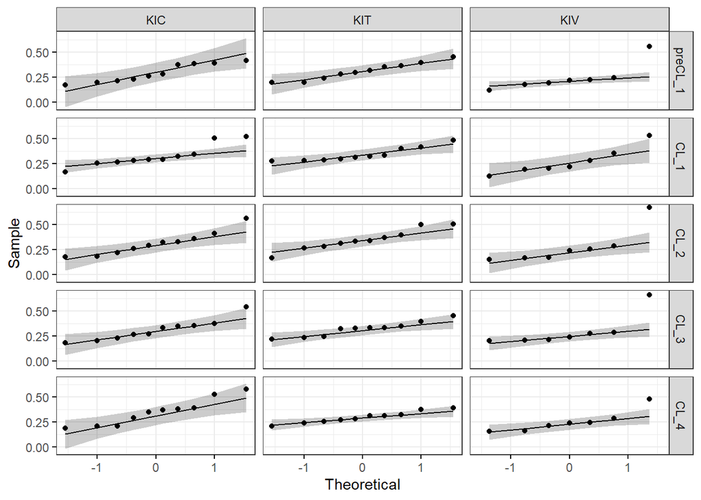

**===HOMOGENEITY OF VARIANCE ASSUMPTION===**

| Measurement | df1 | df2 | statistic | p |
| --- | --- | --- | --- | --- |
| preCL_1 | 2 | 24 | 0.062 | 0.940 |
| CL_1 | 2 | 24 | 0.548 | 0.585 |
| CL_2 | 2 | 24 | 0.179 | 0.837 |
| CL_3 | 2 | 24 | 0.389 | 0.682 |
| CL_4 | 2 | 24 | 1.671 | 0.209 |

##### Mixed ANOVA

| Effect | DFn | DFd | F | p | p..05 | ges |
| --- | --- | --- | --- | --- | --- | --- |
| Group | 2 | 24 | 0.679 | 0.517 |  | 0.043 |
| Measurement | 4 | 96 | 1.101 | 0.361 |  | 0.009 |
| Group:Measurement | 8 | 96 | 1.213 | 0.299 |  | 0.020 |

##### Post-hoc Tests

**===SIGNIFICANT TWO-WAY INTERACTION===**

**=EFFECT OF GROUP AT EACH MEASUREMENT=**

| Measurement | Effect | DFn | DFd | p | p..05 | ges | p.adj |
| --- | --- | --- | --- | --- | --- | --- | --- |
| preCL_1 | Group | 2 | 24 | 0.469 |  | 0.061 | 1.000 |
| CL_1 | Group | 2 | 24 | 0.400 |  | 0.073 | 1.000 |
| CL_2 | Group | 2 | 24 | 0.558 |  | 0.047 | 1.000 |
| CL_3 | Group | 2 | 24 | 0.909 |  | 0.008 | 1.000 |
| CL_4 | Group | 2 | 24 | 0.191 |  | 0.129 | 0.955 |

**=PAIRWISE COMPARISONS BETWEEN GROUP LEVELS=**

| Measurement | .y. | group1 | group2 | n1 | n2 | statistic | df | p | p.adj | p.adj.signif | effsize | magnitude |
| --- | --- | --- | --- | --- | --- | --- | --- | --- | --- | --- | --- | --- |
| preCL_1 | VectorStrenght | KIC | KIT | 10 | 10 | -0.468 | 17.875 | 0.646 | 1.000 | ns | -0.209 | small |
| preCL_1 | VectorStrenght | KIC | KIV | 10 | 7 | 0.737 | 9.361 | 0.479 | 1.000 | ns | 0.376 | small |
| preCL_1 | VectorStrenght | KIT | KIV | 10 | 7 | 1.052 | 8.863 | 0.320 | 0.960 | ns | 0.541 | moderate |
| CL_1 | VectorStrenght | KIC | KIT | 10 | 10 | -0.427 | 15.165 | 0.675 | 1.000 | ns | -0.191 | negligible |
| CL_1 | VectorStrenght | KIC | KIV | 10 | 7 | 0.844 | 11.284 | 0.416 | 1.000 | ns | 0.423 | small |
| CL_1 | VectorStrenght | KIT | KIV | 10 | 7 | 1.256 | 8.244 | 0.244 | 0.732 | ns | 0.650 | moderate |
| CL_2 | VectorStrenght | KIC | KIT | 10 | 10 | -0.739 | 17.768 | 0.470 | 1.000 | ns | -0.330 | small |
| CL_2 | VectorStrenght | KIC | KIV | 10 | 7 | 0.435 | 9.461 | 0.673 | 1.000 | ns | 0.222 | small |
| CL_2 | VectorStrenght | KIT | KIV | 10 | 7 | 0.926 | 8.780 | 0.379 | 1.000 | ns | 0.476 | small |
| CL_3 | VectorStrenght | KIC | KIT | 10 | 10 | -0.284 | 16.055 | 0.780 | 1.000 | ns | -0.127 | negligible |
| CL_3 | VectorStrenght | KIC | KIV | 10 | 7 | 0.183 | 9.460 | 0.859 | 1.000 | ns | 0.093 | negligible |
| CL_3 | VectorStrenght | KIT | KIV | 10 | 7 | 0.369 | 7.703 | 0.722 | 1.000 | ns | 0.192 | negligible |
| CL_4 | VectorStrenght | KIC | KIT | 10 | 10 | 1.178 | 12.287 | 0.261 | 0.783 | ns | 0.527 | moderate |
| CL_4 | VectorStrenght | KIC | KIV | 10 | 7 | 1.606 | 14.399 | 0.130 | 0.390 | ns | 0.779 | moderate |
| CL_4 | VectorStrenght | KIT | KIV | 10 | 7 | 0.906 | 8.286 | 0.391 | 1.000 | ns | 0.468 | small |

**=EFFECT OF MEASUREMENT AT EACH LEVEL OF GROUP=**

| Group | Effect | DFn | DFd | F | p | p..05 | ges | p.adj |
| --- | --- | --- | --- | --- | --- | --- | --- | --- |
| KIC | Measurement | 4 | 36 | 1.519 | 0.217 |  | 0.031 | 0.651 |
| KIT | Measurement | 4 | 36 | 1.157 | 0.346 |  | 0.058 | 1.000 |
| KIV | Measurement | 4 | 24 | 0.887 | 0.487 |  | 0.015 | 1.000 |

**=PAIRWISE COMPARISONS BETWEEN MEASUREMENTS AT EACH GROUP LEVELS=**

| Group | .y. | group1 | group2 | n1 | n2 | statistic | df | p | p.adj | p.adj.signif | effsize | magnitude |
| --- | --- | --- | --- | --- | --- | --- | --- | --- | --- | --- | --- | --- |
| KIC | VectorStrenght | preCL_1 | CL_1 | 10 | 10 | -1.076 | 9 | 0.310 | 1.000 | ns | -0.340 | small |
| KIC | VectorStrenght | preCL_1 | CL_2 | 10 | 10 | -0.737 | 9 | 0.480 | 1.000 | ns | -0.233 | small |
| KIC | VectorStrenght | preCL_1 | CL_3 | 10 | 10 | -0.472 | 9 | 0.648 | 1.000 | ns | -0.149 | negligible |
| KIC | VectorStrenght | preCL_1 | CL_4 | 10 | 10 | -1.767 | 9 | 0.111 | 1.000 | ns | -0.559 | moderate |
| KIC | VectorStrenght | CL_1 | CL_2 | 10 | 10 | 0.651 | 9 | 0.531 | 1.000 | ns | 0.206 | small |
| KIC | VectorStrenght | CL_1 | CL_3 | 10 | 10 | 0.585 | 9 | 0.573 | 1.000 | ns | 0.185 | negligible |
| KIC | VectorStrenght | CL_1 | CL_4 | 10 | 10 | -1.571 | 9 | 0.151 | 1.000 | ns | -0.497 | small |
| KIC | VectorStrenght | CL_2 | CL_3 | 10 | 10 | 0.160 | 9 | 0.876 | 1.000 | ns | 0.051 | negligible |
| KIC | VectorStrenght | CL_2 | CL_4 | 10 | 10 | -1.823 | 9 | 0.102 | 1.000 | ns | -0.577 | moderate |
| KIC | VectorStrenght | CL_3 | CL_4 | 10 | 10 | -1.884 | 9 | 0.092 | 0.923 | ns | -0.596 | moderate |
| KIT | VectorStrenght | preCL_1 | CL_1 | 10 | 10 | -1.836 | 9 | 0.100 | 0.995 | ns | -0.581 | moderate |
| KIT | VectorStrenght | preCL_1 | CL_2 | 10 | 10 | -1.688 | 9 | 0.126 | 1.000 | ns | -0.534 | moderate |
| KIT | VectorStrenght | preCL_1 | CL_3 | 10 | 10 | -0.333 | 9 | 0.747 | 1.000 | ns | -0.105 | negligible |
| KIT | VectorStrenght | preCL_1 | CL_4 | 10 | 10 | 0.427 | 9 | 0.680 | 1.000 | ns | 0.135 | negligible |
| KIT | VectorStrenght | CL_1 | CL_2 | 10 | 10 | -0.336 | 9 | 0.744 | 1.000 | ns | -0.106 | negligible |
| KIT | VectorStrenght | CL_1 | CL_3 | 10 | 10 | 0.699 | 9 | 0.502 | 1.000 | ns | 0.221 | small |
| KIT | VectorStrenght | CL_1 | CL_4 | 10 | 10 | 1.545 | 9 | 0.157 | 1.000 | ns | 0.489 | small |
| KIT | VectorStrenght | CL_2 | CL_3 | 10 | 10 | 1.168 | 9 | 0.273 | 1.000 | ns | 0.369 | small |
| KIT | VectorStrenght | CL_2 | CL_4 | 10 | 10 | 1.524 | 9 | 0.162 | 1.000 | ns | 0.482 | small |
| KIT | VectorStrenght | CL_3 | CL_4 | 10 | 10 | 0.716 | 9 | 0.492 | 1.000 | ns | 0.226 | small |
| KIV | VectorStrenght | preCL_1 | CL_1 | 7 | 7 | -0.603 | 6 | 0.568 | 1.000 | ns | -0.228 | small |
| KIV | VectorStrenght | preCL_1 | CL_2 | 7 | 7 | -0.989 | 6 | 0.361 | 1.000 | ns | -0.374 | small |
| KIV | VectorStrenght | preCL_1 | CL_3 | 7 | 7 | -2.126 | 6 | 0.078 | 0.777 | ns | -0.803 | large |
| KIV | VectorStrenght | preCL_1 | CL_4 | 7 | 7 | -0.309 | 6 | 0.768 | 1.000 | ns | -0.117 | negligible |
| KIV | VectorStrenght | CL_1 | CL_2 | 7 | 7 | -0.287 | 6 | 0.784 | 1.000 | ns | -0.108 | negligible |
| KIV | VectorStrenght | CL_1 | CL_3 | 7 | 7 | -0.993 | 6 | 0.359 | 1.000 | ns | -0.375 | small |
| KIV | VectorStrenght | CL_1 | CL_4 | 7 | 7 | 0.477 | 6 | 0.650 | 1.000 | ns | 0.180 | negligible |
| KIV | VectorStrenght | CL_2 | CL_3 | 7 | 7 | -1.144 | 6 | 0.296 | 1.000 | ns | -0.432 | small |
| KIV | VectorStrenght | CL_2 | CL_4 | 7 | 7 | 0.613 | 6 | 0.562 | 1.000 | ns | 0.232 | small |
| KIV | VectorStrenght | CL_3 | CL_4 | 7 | 7 | 1.548 | 6 | 0.173 | 1.000 | ns | 0.585 | moderate |

**===NON-SIGNIFICANT TWO-WAY INTERACTION===**

**=MAIN EFFECT OF MEASUREMENT=**

| .y. | group1 | group2 | n1 | n2 | statistic | df | p | p.adj | p.adj.signif |
| --- | --- | --- | --- | --- | --- | --- | --- | --- | --- |
| VectorStrenght | preCL_1 | CL_1 | 27 | 27 | -1.8847473 | 26 | 0.071 | 0.707 | ns |
| VectorStrenght | preCL_1 | CL_2 | 27 | 27 | -1.9990866 | 26 | 0.056 | 0.562 | ns |
| VectorStrenght | preCL_1 | CL_3 | 27 | 27 | -1.3041306 | 26 | 0.204 | 1.000 | ns |
| VectorStrenght | preCL_1 | CL_4 | 27 | 27 | -0.9500565 | 26 | 0.351 | 1.000 | ns |
| VectorStrenght | CL_1 | CL_2 | 27 | 27 | -0.1083828 | 26 | 0.915 | 1.000 | ns |
| VectorStrenght | CL_1 | CL_3 | 27 | 27 | 0.3742096 | 26 | 0.711 | 1.000 | ns |
| VectorStrenght | CL_1 | CL_4 | 27 | 27 | 0.6009291 | 26 | 0.553 | 1.000 | ns |
| VectorStrenght | CL_2 | CL_3 | 27 | 27 | 0.5668373 | 26 | 0.576 | 1.000 | ns |
| VectorStrenght | CL_2 | CL_4 | 27 | 27 | 0.5685038 | 26 | 0.575 | 1.000 | ns |
| VectorStrenght | CL_3 | CL_4 | 27 | 27 | 0.2096775 | 26 | 0.836 | 1.000 | ns |

**=MAIN EFFECT OF GROUP=**

.y.

group1

group2

n1

n2

p

p.signif

p.adj

p.adj.signif

VectorStrenght

KIC

KIT

50

50

0.7800

ns

1.0000

ns

VectorStrenght

KIC

KIV

50

35

0.0480

0.1440

ns

VectorStrenght

KIT

KIV

50

35

0.0261

0.0783

ns

##### Plots

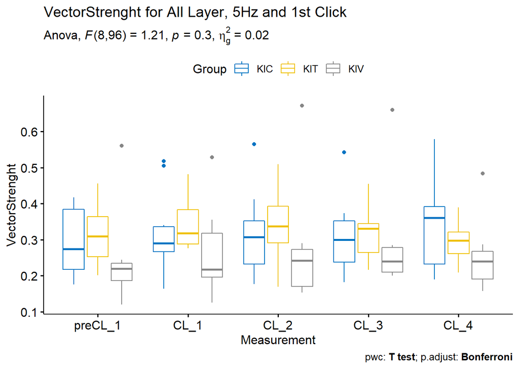

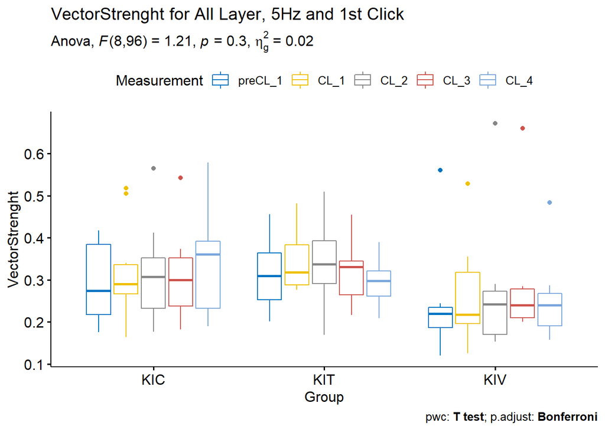

### I_II Layer

#### VectorStrenght

##### Assumptions Check

**===OUTLIERS===**

| Group | Measurement | Animal | VectorStrenght | is.outlier | is.extreme |
| --- | --- | --- | --- | --- | --- |
| KIC | preCL_1 | KIC04 | 0.173854 | TRUE | FALSE |
| KIC | preCL_1 | KIC12 | 0.220316 | TRUE | TRUE |
| KIT | CL_3 | KIT01 | 0.025297 | TRUE | FALSE |

**===NORMALITY ASSUMPTION===**

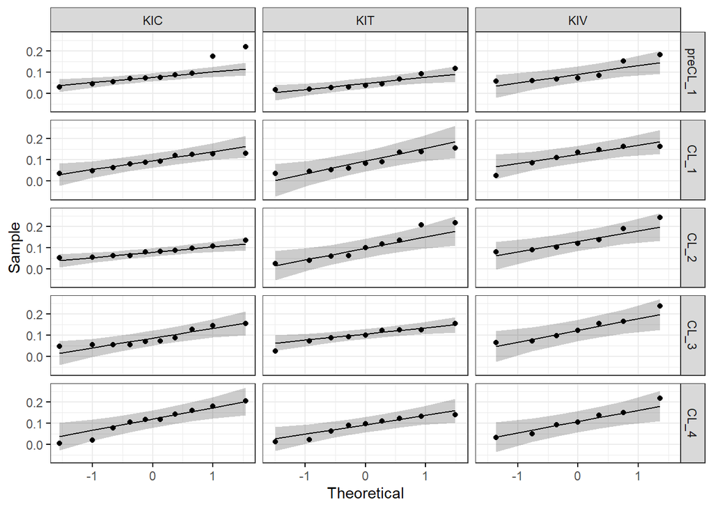

**===HOMOGENEITY OF VARIANCE ASSUMPTION===**

| Measurement | df1 | df2 | statistic | p |
| --- | --- | --- | --- | --- |
| preCL_1 | 2 | 23 | 0.238 | 0.790 |
| CL_1 | 2 | 23 | 0.316 | 0.732 |
| CL_2 | 2 | 23 | 2.612 | 0.095 |
| CL_3 | 2 | 23 | 0.821 | 0.452 |
| CL_4 | 2 | 23 | 0.314 | 0.734 |

##### Mixed ANOVA

Effect

DFn

DFd

F

p

p..05

ges

Group

2

23

1.612

0.221

0.071

Measurement

4

92

2.481

0.049

0.047

Group:Measurement

8

92

1.528

0.158

0.057

##### Post-hoc Tests

**===SIGNIFICANT TWO-WAY INTERACTION===**

**=EFFECT OF GROUP AT EACH MEASUREMENT=**

| Measurement | Effect | DFn | DFd | p | p..05 | ges | p.adj |
| --- | --- | --- | --- | --- | --- | --- | --- |
| preCL_1 | Group | 2 | 23 | 0.122 |  | 0.167 | 0.610 |
| CL_1 | Group | 2 | 23 | 0.331 |  | 0.092 | 1.000 |
| CL_2 | Group | 2 | 23 | 0.131 |  | 0.162 | 0.655 |
| CL_3 | Group | 2 | 23 | 0.176 |  | 0.140 | 0.880 |
| CL_4 | Group | 2 | 23 | 0.596 |  | 0.044 | 1.000 |

**=PAIRWISE COMPARISONS BETWEEN GROUP LEVELS=**

| Measurement | .y. | group1 | group2 | n1 | n2 | statistic | df | p | p.adj | p.adj.signif | effsize | magnitude |
| --- | --- | --- | --- | --- | --- | --- | --- | --- | --- | --- | --- | --- |
| preCL_1 | VectorStrenght | KIC | KIT | 10 | 10 | 1.918 | 14.753 | 0.075 | 0.224 | ns | 0.870 | large |
| preCL_1 | VectorStrenght | KIC | KIV | 10 | 7 | -0.128 | 14.389 | 0.900 | 1.000 | ns | -0.062 | negligible |
| preCL_1 | VectorStrenght | KIT | KIV | 10 | 7 | -2.068 | 10.304 | 0.065 | 0.194 | ns | -1.065 | large |
| CL_1 | VectorStrenght | KIC | KIT | 10 | 10 | 0.158 | 15.011 | 0.876 | 1.000 | ns | 0.073 | negligible |
| CL_1 | VectorStrenght | KIC | KIV | 10 | 7 | -1.245 | 9.916 | 0.242 | 0.726 | ns | -0.632 | moderate |
| CL_1 | VectorStrenght | KIT | KIV | 10 | 7 | -1.249 | 12.239 | 0.235 | 0.705 | ns | -0.634 | moderate |
| CL_2 | VectorStrenght | KIC | KIT | 10 | 10 | -1.013 | 10.043 | 0.335 | 1.000 | ns | -0.474 | small |
| CL_2 | VectorStrenght | KIC | KIV | 10 | 7 | -2.336 | 7.691 | 0.049 | 0.147 | ns | -1.217 | large |
| CL_2 | VectorStrenght | KIT | KIV | 10 | 7 | -0.951 | 13.852 | 0.358 | 1.000 | ns | -0.474 | small |
| CL_3 | VectorStrenght | KIC | KIT | 10 | 10 | -0.748 | 16.956 | 0.465 | 1.000 | ns | -0.343 | small |
| CL_3 | VectorStrenght | KIC | KIV | 10 | 7 | -1.651 | 9.641 | 0.131 | 0.393 | ns | -0.841 | large |
| CL_3 | VectorStrenght | KIT | KIV | 10 | 7 | -1.143 | 9.519 | 0.281 | 0.843 | ns | -0.592 | moderate |
| CL_4 | VectorStrenght | KIC | KIT | 10 | 10 | 0.977 | 16.356 | 0.343 | 1.000 | ns | 0.445 | small |
| CL_4 | VectorStrenght | KIC | KIV | 10 | 7 | 0.024 | 13.256 | 0.982 | 1.000 | ns | 0.012 | negligible |
| CL_4 | VectorStrenght | KIT | KIV | 10 | 7 | -0.855 | 10.795 | 0.411 | 1.000 | ns | -0.439 | small |

**=EFFECT OF MEASUREMENT AT EACH LEVEL OF GROUP=**

Group

Effect

DFn

DFd

F

p

p..05

ges

p.adj

KIC

Measurement

4

36

0.842

0.508

0.051

1.000

KIT

Measurement

4

32

3.803

0.012

0.159

0.036

KIV

Measurement

4

24

1.198

0.337

0.073

1.000

**=PAIRWISE COMPARISONS BETWEEN MEASUREMENTS AT EACH GROUP LEVELS=**

| Group | .y. | group1 | group2 | n1 | n2 | statistic | df | p | p.adj | p.adj.signif | effsize | magnitude |
| --- | --- | --- | --- | --- | --- | --- | --- | --- | --- | --- | --- | --- |
| KIC | VectorStrenght | preCL_1 | CL_1 | 10 | 10 | 0.044 | 9 | 0.966 | 1.000 | ns | 0.014 | negligible |
| KIC | VectorStrenght | preCL_1 | CL_2 | 10 | 10 | 0.532 | 9 | 0.607 | 1.000 | ns | 0.168 | negligible |
| KIC | VectorStrenght | preCL_1 | CL_3 | 10 | 10 | 0.277 | 9 | 0.788 | 1.000 | ns | 0.087 | negligible |
| KIC | VectorStrenght | preCL_1 | CL_4 | 10 | 10 | -0.776 | 9 | 0.457 | 1.000 | ns | -0.246 | small |
| KIC | VectorStrenght | CL_1 | CL_2 | 10 | 10 | 0.807 | 9 | 0.440 | 1.000 | ns | 0.255 | small |
| KIC | VectorStrenght | CL_1 | CL_3 | 10 | 10 | 0.272 | 9 | 0.792 | 1.000 | ns | 0.086 | negligible |
| KIC | VectorStrenght | CL_1 | CL_4 | 10 | 10 | -1.224 | 9 | 0.252 | 1.000 | ns | -0.387 | small |
| KIC | VectorStrenght | CL_2 | CL_3 | 10 | 10 | -0.737 | 9 | 0.480 | 1.000 | ns | -0.233 | small |
| KIC | VectorStrenght | CL_2 | CL_4 | 10 | 10 | -1.510 | 9 | 0.165 | 1.000 | ns | -0.478 | small |
| KIC | VectorStrenght | CL_3 | CL_4 | 10 | 10 | -1.339 | 9 | 0.213 | 1.000 | ns | -0.424 | small |
| KIT | VectorStrenght | preCL_1 | CL_1 | 10 | 10 | -2.382 | 8 | 0.044 | 0.444 | ns | -0.794 | moderate |
| KIT | VectorStrenght | preCL_1 | CL_2 | 10 | 10 | -2.411 | 8 | 0.042 | 0.424 | ns | -0.804 | large |
| KIT | VectorStrenght | preCL_1 | CL_3 | 10 | 10 | -2.674 | 8 | 0.028 | 0.282 | ns | -0.891 | large |
| KIT | VectorStrenght | preCL_1 | CL_4 | 10 | 10 | -2.050 | 8 | 0.074 | 0.745 | ns | -0.683 | moderate |
| KIT | VectorStrenght | CL_1 | CL_2 | 10 | 10 | -1.099 | 8 | 0.304 | 1.000 | ns | -0.366 | small |
| KIT | VectorStrenght | CL_1 | CL_3 | 10 | 10 | -1.179 | 8 | 0.272 | 1.000 | ns | -0.393 | small |
| KIT | VectorStrenght | CL_1 | CL_4 | 10 | 10 | 0.081 | 8 | 0.937 | 1.000 | ns | 0.027 | negligible |
| KIT | VectorStrenght | CL_2 | CL_3 | 10 | 10 | 0.356 | 8 | 0.731 | 1.000 | ns | 0.119 | negligible |
| KIT | VectorStrenght | CL_2 | CL_4 | 10 | 10 | 1.506 | 8 | 0.170 | 1.000 | ns | 0.502 | moderate |
| KIT | VectorStrenght | CL_3 | CL_4 | 10 | 10 | 1.375 | 8 | 0.206 | 1.000 | ns | 0.458 | small |
| KIV | VectorStrenght | preCL_1 | CL_1 | 7 | 7 | -0.934 | 6 | 0.386 | 1.000 | ns | -0.353 | small |
| KIV | VectorStrenght | preCL_1 | CL_2 | 7 | 7 | -4.065 | 6 | 0.007 | 0.066 | ns | -1.537 | large |
| KIV | VectorStrenght | preCL_1 | CL_3 | 7 | 7 | -1.730 | 6 | 0.134 | 1.000 | ns | -0.654 | moderate |
| KIV | VectorStrenght | preCL_1 | CL_4 | 7 | 7 | -0.675 | 6 | 0.525 | 1.000 | ns | -0.255 | small |
| KIV | VectorStrenght | CL_1 | CL_2 | 7 | 7 | -0.729 | 6 | 0.493 | 1.000 | ns | -0.276 | small |
| KIV | VectorStrenght | CL_1 | CL_3 | 7 | 7 | -0.459 | 6 | 0.662 | 1.000 | ns | -0.173 | negligible |
| KIV | VectorStrenght | CL_1 | CL_4 | 7 | 7 | 0.301 | 6 | 0.773 | 1.000 | ns | 0.114 | negligible |
| KIV | VectorStrenght | CL_2 | CL_3 | 7 | 7 | 0.433 | 6 | 0.680 | 1.000 | ns | 0.164 | negligible |
| KIV | VectorStrenght | CL_2 | CL_4 | 7 | 7 | 1.384 | 6 | 0.216 | 1.000 | ns | 0.523 | moderate |
| KIV | VectorStrenght | CL_3 | CL_4 | 7 | 7 | 1.056 | 6 | 0.331 | 1.000 | ns | 0.399 | small |

**===NON-SIGNIFICANT TWO-WAY INTERACTION===**

**=MAIN EFFECT OF MEASUREMENT=**

| .y. | group1 | group2 | n1 | n2 | statistic | df | p | p.adj | p.adj.signif |
| --- | --- | --- | --- | --- | --- | --- | --- | --- | --- |
| VectorStrenght | preCL_1 | CL_1 | 27 | 27 | -1.6365257 | 25 | 0.114 | 1.000 | ns |
| VectorStrenght | preCL_1 | CL_2 | 27 | 27 | -2.1216364 | 25 | 0.044 | 0.440 | ns |
| VectorStrenght | preCL_1 | CL_3 | 27 | 27 | -2.2632124 | 25 | 0.033 | 0.326 | ns |
| VectorStrenght | preCL_1 | CL_4 | 27 | 27 | -1.9187662 | 25 | 0.066 | 0.665 | ns |
| VectorStrenght | CL_1 | CL_2 | 27 | 27 | -0.7616682 | 25 | 0.453 | 1.000 | ns |
| VectorStrenght | CL_1 | CL_3 | 27 | 27 | -0.6876869 | 25 | 0.498 | 1.000 | ns |
| VectorStrenght | CL_1 | CL_4 | 27 | 27 | -0.5920471 | 25 | 0.559 | 1.000 | ns |
| VectorStrenght | CL_2 | CL_3 | 27 | 27 | 0.1614650 | 25 | 0.873 | 1.000 | ns |
| VectorStrenght | CL_2 | CL_4 | 27 | 27 | 0.1594418 | 25 | 0.875 | 1.000 | ns |
| VectorStrenght | CL_3 | CL_4 | 27 | 27 | 0.0658997 | 25 | 0.948 | 1.000 | ns |

**=MAIN EFFECT OF GROUP=**

.y.

group1

group2

n1

n2

p

p.signif

p.adj

p.adj.signif

VectorStrenght

KIC

KIT

50

50

0.54000

ns

1.0000

ns

VectorStrenght

KIC

KIV

50

35

0.02150

0.0646

ns

VectorStrenght

KIT

KIV

50

35

0.00532

0.0160

##### Plots

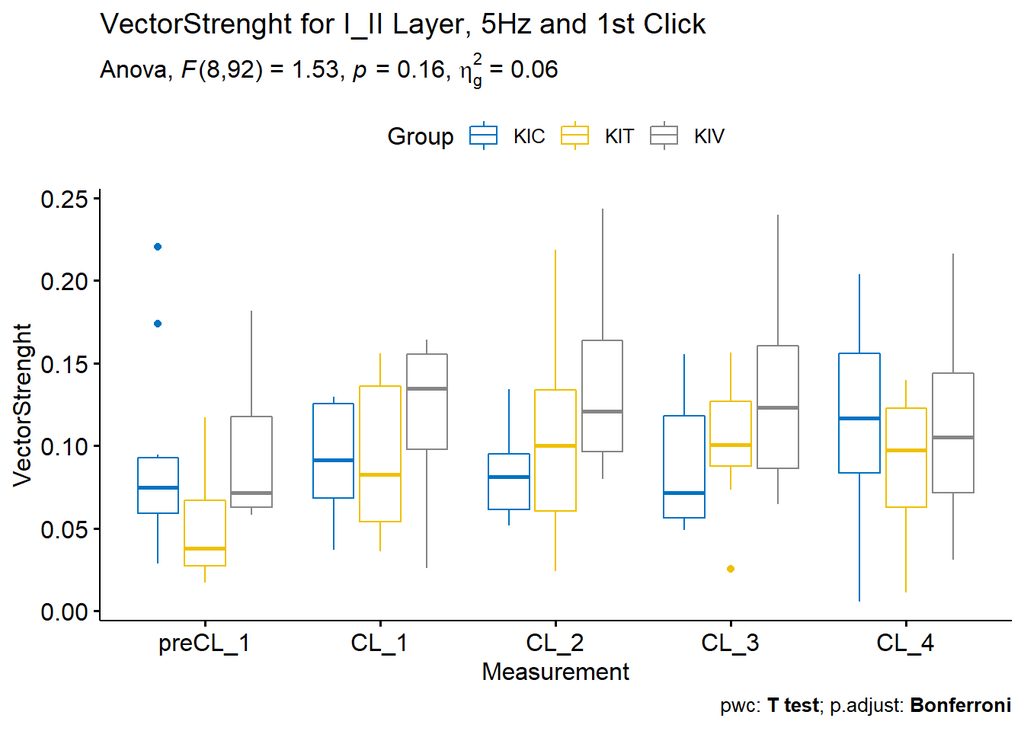

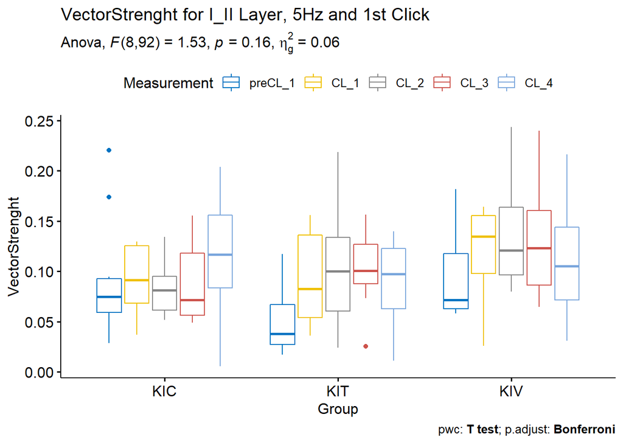

### IV Layer

#### VectorStrenght

##### Assumptions Check

**===OUTLIERS===**

| Group | Measurement | Animal | VectorStrenght | is.outlier | is.extreme |
| --- | --- | --- | --- | --- | --- |
| KIT | preCL_1 | KIT03 | 0.418873 | TRUE | TRUE |
| KIT | preCL_1 | KIT11 | 0.259655 | TRUE | FALSE |
| KIV | preCL_1 | KIV12 | 0.479632 | TRUE | TRUE |
| KIV | CL_1 | KIV12 | 0.503338 | TRUE | FALSE |
| KIV | CL_2 | KIV12 | 0.545991 | TRUE | TRUE |
| KIC | CL_3 | KIC11 | 0.404824 | TRUE | FALSE |
| KIV | CL_3 | KIV12 | 0.531562 | TRUE | FALSE |
| KIC | CL_4 | KIC11 | 0.492905 | TRUE | TRUE |
| KIV | CL_4 | KIV03 | 0.067506 | TRUE | FALSE |
| KIV | CL_4 | KIV12 | 0.377816 | TRUE | TRUE |

**===NORMALITY ASSUMPTION===**

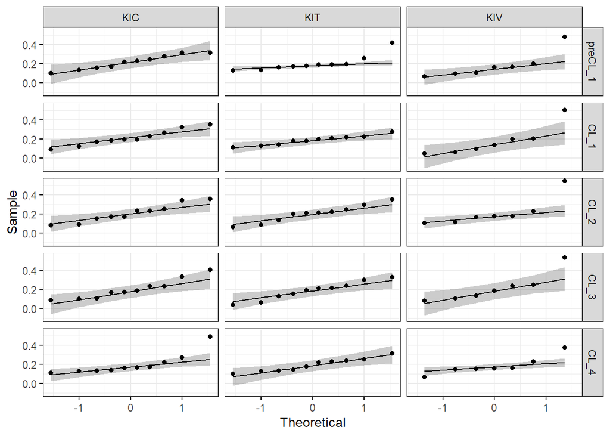

**===HOMOGENEITY OF VARIANCE ASSUMPTION===**

| Measurement | df1 | df2 | statistic | p |
| --- | --- | --- | --- | --- |
| preCL_1 | 2 | 24 | 0.431 | 0.655 |
| CL_1 | 2 | 24 | 1.559 | 0.231 |
| CL_2 | 2 | 24 | 0.099 | 0.906 |
| CL_3 | 2 | 24 | 0.301 | 0.743 |
| CL_4 | 2 | 24 | 0.029 | 0.971 |

##### Mixed ANOVA

| Effect | DFn | DFd | F | p | p..05 | ges |
| --- | --- | --- | --- | --- | --- | --- |
| Group | 2 | 24 | 0.057 | 0.945 |  | 0.004 |
| Measurement | 4 | 96 | 0.678 | 0.609 |  | 0.004 |
| Group:Measurement | 8 | 96 | 0.697 | 0.693 |  | 0.008 |

##### Post-hoc Tests

**===SIGNIFICANT TWO-WAY INTERACTION===**

**=EFFECT OF GROUP AT EACH MEASUREMENT=**

| Measurement | Effect | DFn | DFd | p | p..05 | ges | p.adj |
| --- | --- | --- | --- | --- | --- | --- | --- |
| preCL_1 | Group | 2 | 24 | 0.790 |  | 0.019 | 1 |
| CL_1 | Group | 2 | 24 | 0.747 |  | 0.024 | 1 |
| CL_2 | Group | 2 | 24 | 0.967 |  | 0.003 | 1 |
| CL_3 | Group | 2 | 24 | 0.854 |  | 0.013 | 1 |
| CL_4 | Group | 2 | 24 | 0.952 |  | 0.004 | 1 |

**=PAIRWISE COMPARISONS BETWEEN GROUP LEVELS=**

| Measurement | .y. | group1 | group2 | n1 | n2 | statistic | df | p | p.adj | p.adj.signif | effsize | magnitude |
| --- | --- | --- | --- | --- | --- | --- | --- | --- | --- | --- | --- | --- |
| preCL_1 | VectorStrenght | KIC | KIT | 10 | 10 | 0.373 | 17.707 | 0.713 | 1 | ns | 0.167 | negligible |
| preCL_1 | VectorStrenght | KIC | KIV | 10 | 7 | 0.578 | 8.412 | 0.579 | 1 | ns | 0.298 | small |
| preCL_1 | VectorStrenght | KIT | KIV | 10 | 7 | 0.339 | 9.100 | 0.742 | 1 | ns | 0.174 | negligible |
| CL_1 | VectorStrenght | KIC | KIT | 10 | 10 | 0.865 | 14.693 | 0.401 | 1 | ns | 0.387 | small |
| CL_1 | VectorStrenght | KIC | KIV | 10 | 7 | 0.522 | 8.345 | 0.615 | 1 | ns | 0.270 | small |
| CL_1 | VectorStrenght | KIT | KIV | 10 | 7 | 0.123 | 6.837 | 0.906 | 1 | ns | 0.065 | negligible |
| CL_2 | VectorStrenght | KIC | KIT | 10 | 10 | 0.159 | 17.948 | 0.876 | 1 | ns | 0.071 | negligible |
| CL_2 | VectorStrenght | KIC | KIV | 10 | 7 | -0.114 | 9.246 | 0.911 | 1 | ns | -0.059 | negligible |
| CL_2 | VectorStrenght | KIT | KIV | 10 | 7 | -0.218 | 8.927 | 0.832 | 1 | ns | -0.112 | negligible |
| CL_3 | VectorStrenght | KIC | KIT | 10 | 10 | 0.354 | 17.808 | 0.727 | 1 | ns | 0.158 | negligible |
| CL_3 | VectorStrenght | KIC | KIV | 10 | 7 | -0.241 | 9.803 | 0.814 | 1 | ns | -0.123 | negligible |
| CL_3 | VectorStrenght | KIT | KIV | 10 | 7 | -0.488 | 9.126 | 0.637 | 1 | ns | -0.250 | small |
| CL_4 | VectorStrenght | KIC | KIT | 10 | 10 | 0.144 | 14.748 | 0.887 | 1 | ns | 0.064 | negligible |
| CL_4 | VectorStrenght | KIC | KIV | 10 | 7 | 0.286 | 14.276 | 0.779 | 1 | ns | 0.139 | negligible |
| CL_4 | VectorStrenght | KIT | KIV | 10 | 7 | 0.204 | 10.070 | 0.843 | 1 | ns | 0.103 | negligible |

**=EFFECT OF MEASUREMENT AT EACH LEVEL OF GROUP=**

| Group | Effect | DFn | DFd | F | p | p..05 | ges | p.adj |
| --- | --- | --- | --- | --- | --- | --- | --- | --- |
| KIC | Measurement | 4 | 36 | 0.221 | 0.925 |  | 0.005 | 1.000 |
| KIT | Measurement | 4 | 36 | 0.392 | 0.813 |  | 0.011 | 1.000 |
| KIV | Measurement | 4 | 24 | 1.622 | 0.201 |  | 0.017 | 0.603 |

**=PAIRWISE COMPARISONS BETWEEN MEASUREMENTS AT EACH GROUP LEVELS=**

| Group | .y. | group1 | group2 | n1 | n2 | statistic | df | p | p.adj | p.adj.signif | effsize | magnitude |
| --- | --- | --- | --- | --- | --- | --- | --- | --- | --- | --- | --- | --- |
| KIC | VectorStrenght | preCL_1 | CL_1 | 10 | 10 | 0.201 | 9 | 0.845 | 1.000 | ns | 0.064 | negligible |
| KIC | VectorStrenght | preCL_1 | CL_2 | 10 | 10 | 0.276 | 9 | 0.789 | 1.000 | ns | 0.087 | negligible |
| KIC | VectorStrenght | preCL_1 | CL_3 | 10 | 10 | 0.702 | 9 | 0.501 | 1.000 | ns | 0.222 | small |
| KIC | VectorStrenght | preCL_1 | CL_4 | 10 | 10 | 0.512 | 9 | 0.621 | 1.000 | ns | 0.162 | negligible |
| KIC | VectorStrenght | CL_1 | CL_2 | 10 | 10 | 0.135 | 9 | 0.896 | 1.000 | ns | 0.043 | negligible |
| KIC | VectorStrenght | CL_1 | CL_3 | 10 | 10 | 0.645 | 9 | 0.535 | 1.000 | ns | 0.204 | small |
| KIC | VectorStrenght | CL_1 | CL_4 | 10 | 10 | 0.552 | 9 | 0.594 | 1.000 | ns | 0.175 | negligible |
| KIC | VectorStrenght | CL_2 | CL_3 | 10 | 10 | 0.600 | 9 | 0.563 | 1.000 | ns | 0.190 | negligible |
| KIC | VectorStrenght | CL_2 | CL_4 | 10 | 10 | 0.439 | 9 | 0.671 | 1.000 | ns | 0.139 | negligible |
| KIC | VectorStrenght | CL_3 | CL_4 | 10 | 10 | 0.012 | 9 | 0.991 | 1.000 | ns | 0.004 | negligible |
| KIT | VectorStrenght | preCL_1 | CL_1 | 10 | 10 | 0.910 | 9 | 0.387 | 1.000 | ns | 0.288 | small |
| KIT | VectorStrenght | preCL_1 | CL_2 | 10 | 10 | -0.007 | 9 | 0.995 | 1.000 | ns | -0.002 | negligible |
| KIT | VectorStrenght | preCL_1 | CL_3 | 10 | 10 | 0.709 | 9 | 0.496 | 1.000 | ns | 0.224 | small |
| KIT | VectorStrenght | preCL_1 | CL_4 | 10 | 10 | 0.291 | 9 | 0.777 | 1.000 | ns | 0.092 | negligible |
| KIT | VectorStrenght | CL_1 | CL_2 | 10 | 10 | -1.160 | 9 | 0.276 | 1.000 | ns | -0.367 | small |
| KIT | VectorStrenght | CL_1 | CL_3 | 10 | 10 | 0.037 | 9 | 0.971 | 1.000 | ns | 0.012 | negligible |
| KIT | VectorStrenght | CL_1 | CL_4 | 10 | 10 | -0.583 | 9 | 0.574 | 1.000 | ns | -0.184 | negligible |
| KIT | VectorStrenght | CL_2 | CL_3 | 10 | 10 | 1.463 | 9 | 0.178 | 1.000 | ns | 0.463 | small |
| KIT | VectorStrenght | CL_2 | CL_4 | 10 | 10 | 0.465 | 9 | 0.653 | 1.000 | ns | 0.147 | negligible |
| KIT | VectorStrenght | CL_3 | CL_4 | 10 | 10 | -0.520 | 9 | 0.616 | 1.000 | ns | -0.164 | negligible |
| KIV | VectorStrenght | preCL_1 | CL_1 | 7 | 7 | 0.240 | 6 | 0.818 | 1.000 | ns | 0.091 | negligible |
| KIV | VectorStrenght | preCL_1 | CL_2 | 7 | 7 | -1.920 | 6 | 0.103 | 1.000 | ns | -0.726 | moderate |
| KIV | VectorStrenght | preCL_1 | CL_3 | 7 | 7 | -2.776 | 6 | 0.032 | 0.322 | ns | -1.049 | large |
| KIV | VectorStrenght | preCL_1 | CL_4 | 7 | 7 | -0.109 | 6 | 0.917 | 1.000 | ns | -0.041 | negligible |
| KIV | VectorStrenght | CL_1 | CL_2 | 7 | 7 | -2.838 | 6 | 0.030 | 0.296 | ns | -1.073 | large |
| KIV | VectorStrenght | CL_1 | CL_3 | 7 | 7 | -2.530 | 6 | 0.045 | 0.447 | ns | -0.956 | large |
| KIV | VectorStrenght | CL_1 | CL_4 | 7 | 7 | -0.268 | 6 | 0.798 | 1.000 | ns | -0.101 | negligible |
| KIV | VectorStrenght | CL_2 | CL_3 | 7 | 7 | 0.008 | 6 | 0.994 | 1.000 | ns | 0.003 | negligible |
| KIV | VectorStrenght | CL_2 | CL_4 | 7 | 7 | 1.195 | 6 | 0.277 | 1.000 | ns | 0.452 | small |
| KIV | VectorStrenght | CL_3 | CL_4 | 7 | 7 | 1.151 | 6 | 0.293 | 1.000 | ns | 0.435 | small |

**===NON-SIGNIFICANT TWO-WAY INTERACTION===**

**=MAIN EFFECT OF MEASUREMENT=**

| .y. | group1 | group2 | n1 | n2 | statistic | df | p | p.adj | p.adj.signif |
| --- | --- | --- | --- | --- | --- | --- | --- | --- | --- |
| VectorStrenght | preCL_1 | CL_1 | 27 | 27 | 0.8133086 | 26 | 0.423 | 1 | ns |
| VectorStrenght | preCL_1 | CL_2 | 27 | 27 | -0.4920977 | 26 | 0.627 | 1 | ns |
| VectorStrenght | preCL_1 | CL_3 | 27 | 27 | 0.2701037 | 26 | 0.789 | 1 | ns |
| VectorStrenght | preCL_1 | CL_4 | 27 | 27 | 0.4944015 | 26 | 0.625 | 1 | ns |
| VectorStrenght | CL_1 | CL_2 | 27 | 27 | -1.6402670 | 26 | 0.113 | 1 | ns |
| VectorStrenght | CL_1 | CL_3 | 27 | 27 | -0.5367124 | 26 | 0.596 | 1 | ns |
| VectorStrenght | CL_1 | CL_4 | 27 | 27 | -0.0863169 | 26 | 0.932 | 1 | ns |
| VectorStrenght | CL_2 | CL_3 | 27 | 27 | 1.2143463 | 26 | 0.236 | 1 | ns |
| VectorStrenght | CL_2 | CL_4 | 27 | 27 | 1.2248309 | 26 | 0.232 | 1 | ns |
| VectorStrenght | CL_3 | CL_4 | 27 | 27 | 0.4050820 | 26 | 0.689 | 1 | ns |

**=MAIN EFFECT OF GROUP=**

| .y. | group1 | group2 | n1 | n2 | p | p.signif | p.adj | p.adj.signif |
| --- | --- | --- | --- | --- | --- | --- | --- | --- |
| VectorStrenght | KIC | KIT | 50 | 50 | 0.495 | ns | 1 | ns |
| VectorStrenght | KIC | KIV | 50 | 35 | 0.595 | ns | 1 | ns |
| VectorStrenght | KIT | KIV | 50 | 35 | 0.930 | ns | 1 | ns |

##### Plots

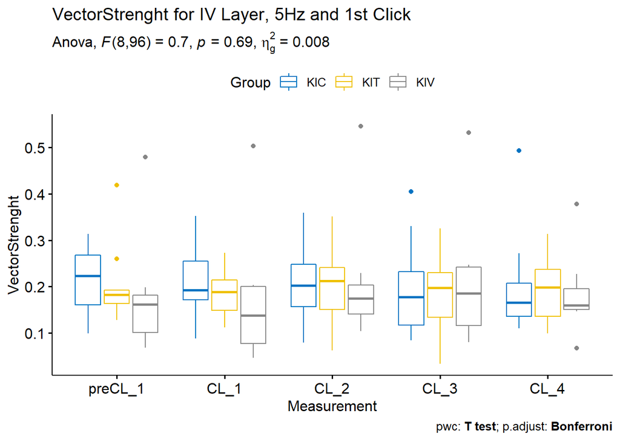

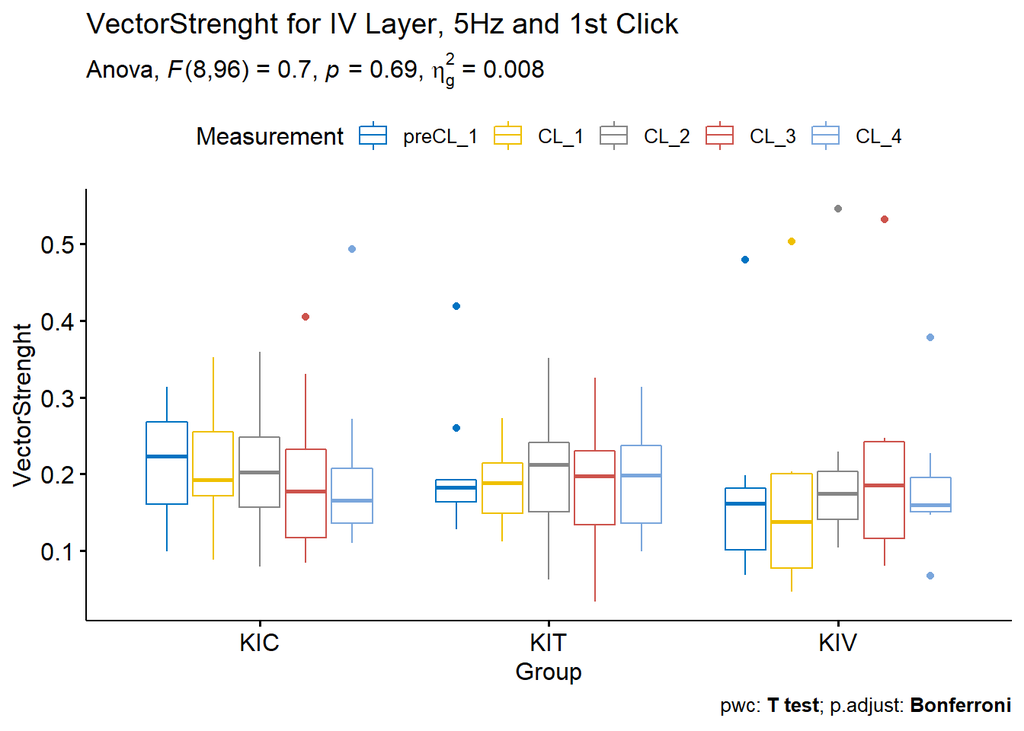

### V Layer

#### VectorStrenght

##### Assumptions Check

**===OUTLIERS===**

| Group | Measurement | Animal | VectorStrenght | is.outlier | is.extreme |
| --- | --- | --- | --- | --- | --- |
| KIT | preCL_1 | KIT02 | 0.391963 | TRUE | FALSE |
| KIT | CL_4 | KIT02 | 0.301422 | TRUE | FALSE |
| KIV | CL_4 | KIV02 | 0.049485 | TRUE | FALSE |
| KIV | CL_4 | KIV04 | 0.236143 | TRUE | FALSE |

**===NORMALITY ASSUMPTION===**

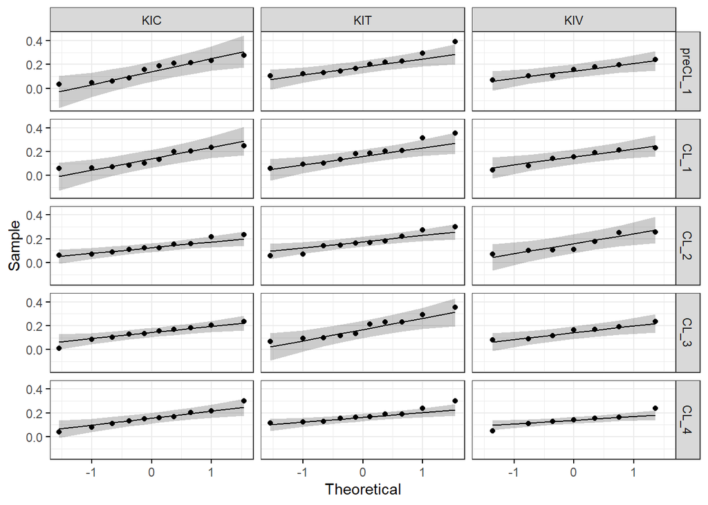

**===HOMOGENEITY OF VARIANCE ASSUMPTION===**

| Measurement | df1 | df2 | statistic | p |
| --- | --- | --- | --- | --- |
| preCL_1 | 2 | 24 | 0.590 | 0.562 |
| CL_1 | 2 | 24 | 0.272 | 0.764 |
| CL_2 | 2 | 24 | 0.255 | 0.777 |
| CL_3 | 2 | 24 | 2.411 | 0.111 |
| CL_4 | 2 | 24 | 0.369 | 0.696 |

##### Mixed ANOVA

| Effect | DFn | DFd | F | p | p..05 | ges |
| --- | --- | --- | --- | --- | --- | --- |
| Group | 2 | 24 | 1.004 | 0.381 |  | 0.061 |
| Measurement | 4 | 96 | 0.552 | 0.698 |  | 0.005 |
| Group:Measurement | 8 | 96 | 0.383 | 0.927 |  | 0.007 |

##### Post-hoc Tests

**===SIGNIFICANT TWO-WAY INTERACTION===**

**=EFFECT OF GROUP AT EACH MEASUREMENT=**

| Measurement | Effect | DFn | DFd | p | p..05 | ges | p.adj |
| --- | --- | --- | --- | --- | --- | --- | --- |
| preCL_1 | Group | 2 | 24 | 0.337 |  | 0.087 | 1 |
| CL_1 | Group | 2 | 24 | 0.464 |  | 0.062 | 1 |
| CL_2 | Group | 2 | 24 | 0.496 |  | 0.057 | 1 |
| CL_3 | Group | 2 | 24 | 0.426 |  | 0.069 | 1 |
| CL_4 | Group | 2 | 24 | 0.509 |  | 0.055 | 1 |

**=PAIRWISE COMPARISONS BETWEEN GROUP LEVELS=**

| Measurement | .y. | group1 | group2 | n1 | n2 | statistic | df | p | p.adj | p.adj.signif | effsize | magnitude |
| --- | --- | --- | --- | --- | --- | --- | --- | --- | --- | --- | --- | --- |
| preCL_1 | VectorStrenght | KIC | KIT | 10 | 10 | -1.253 | 17.987 | 0.226 | 0.678 | ns | -0.560 | moderate |
| preCL_1 | VectorStrenght | KIC | KIV | 10 | 7 | 0.000 | 14.992 | 1.000 | 1.000 | ns | 0.000 | negligible |
| preCL_1 | VectorStrenght | KIT | KIV | 10 | 7 | 1.356 | 15.000 | 0.195 | 0.585 | ns | 0.646 | moderate |
| CL_1 | VectorStrenght | KIC | KIT | 10 | 10 | -1.155 | 17.157 | 0.264 | 0.792 | ns | -0.517 | moderate |
| CL_1 | VectorStrenght | KIC | KIV | 10 | 7 | -0.273 | 13.832 | 0.789 | 1.000 | ns | -0.134 | negligible |
| CL_1 | VectorStrenght | KIT | KIV | 10 | 7 | 0.872 | 14.943 | 0.397 | 1.000 | ns | 0.418 | small |
| CL_2 | VectorStrenght | KIC | KIT | 10 | 10 | -1.237 | 16.604 | 0.233 | 0.699 | ns | -0.553 | moderate |
| CL_2 | VectorStrenght | KIC | KIV | 10 | 7 | -0.556 | 10.646 | 0.590 | 1.000 | ns | -0.280 | small |
| CL_2 | VectorStrenght | KIT | KIV | 10 | 7 | 0.500 | 13.251 | 0.625 | 1.000 | ns | 0.246 | small |
| CL_3 | VectorStrenght | KIC | KIT | 10 | 10 | -1.194 | 15.700 | 0.250 | 0.750 | ns | -0.534 | moderate |
| CL_3 | VectorStrenght | KIC | KIV | 10 | 7 | -0.321 | 14.013 | 0.753 | 1.000 | ns | -0.157 | negligible |
| CL_3 | VectorStrenght | KIT | KIV | 10 | 7 | 0.915 | 14.739 | 0.375 | 1.000 | ns | 0.432 | small |
| CL_4 | VectorStrenght | KIC | KIT | 10 | 10 | -0.704 | 16.898 | 0.491 | 1.000 | ns | -0.315 | small |
| CL_4 | VectorStrenght | KIC | KIV | 10 | 7 | 0.491 | 14.808 | 0.631 | 1.000 | ns | 0.236 | small |
| CL_4 | VectorStrenght | KIT | KIV | 10 | 7 | 1.299 | 13.121 | 0.216 | 0.648 | ns | 0.640 | moderate |

**=EFFECT OF MEASUREMENT AT EACH LEVEL OF GROUP=**

| Group | Effect | DFn | DFd | F | p | p..05 | ges | p.adj |
| --- | --- | --- | --- | --- | --- | --- | --- | --- |
| KIC | Measurement | 4 | 36 | 0.561 | 0.693 |  | 0.014 | 1 |
| KIT | Measurement | 4 | 36 | 0.882 | 0.484 |  | 0.016 | 1 |
| KIV | Measurement | 4 | 24 | 0.094 | 0.983 |  | 0.006 | 1 |

**=PAIRWISE COMPARISONS BETWEEN MEASUREMENTS AT EACH GROUP LEVELS=**

| Group | .y. | group1 | group2 | n1 | n2 | statistic | df | p | p.adj | p.adj.signif | effsize | magnitude |
| --- | --- | --- | --- | --- | --- | --- | --- | --- | --- | --- | --- | --- |
| KIC | VectorStrenght | preCL_1 | CL_1 | 10 | 10 | 0.647 | 9 | 0.534 | 1.000 | ns | 0.205 | small |
| KIC | VectorStrenght | preCL_1 | CL_2 | 10 | 10 | 0.980 | 9 | 0.353 | 1.000 | ns | 0.310 | small |
| KIC | VectorStrenght | preCL_1 | CL_3 | 10 | 10 | 0.512 | 9 | 0.621 | 1.000 | ns | 0.162 | negligible |
| KIC | VectorStrenght | preCL_1 | CL_4 | 10 | 10 | -0.230 | 9 | 0.823 | 1.000 | ns | -0.073 | negligible |
| KIC | VectorStrenght | CL_1 | CL_2 | 10 | 10 | 0.607 | 9 | 0.559 | 1.000 | ns | 0.192 | negligible |
| KIC | VectorStrenght | CL_1 | CL_3 | 10 | 10 | 0.036 | 9 | 0.972 | 1.000 | ns | 0.011 | negligible |
| KIC | VectorStrenght | CL_1 | CL_4 | 10 | 10 | -0.699 | 9 | 0.502 | 1.000 | ns | -0.221 | small |
| KIC | VectorStrenght | CL_2 | CL_3 | 10 | 10 | -0.648 | 9 | 0.533 | 1.000 | ns | -0.205 | small |
| KIC | VectorStrenght | CL_2 | CL_4 | 10 | 10 | -1.244 | 9 | 0.245 | 1.000 | ns | -0.394 | small |
| KIC | VectorStrenght | CL_3 | CL_4 | 10 | 10 | -0.965 | 9 | 0.360 | 1.000 | ns | -0.305 | small |
| KIT | VectorStrenght | preCL_1 | CL_1 | 10 | 10 | 0.928 | 9 | 0.378 | 1.000 | ns | 0.293 | small |
| KIT | VectorStrenght | preCL_1 | CL_2 | 10 | 10 | 2.263 | 9 | 0.050 | 0.499 | ns | 0.716 | moderate |
| KIT | VectorStrenght | preCL_1 | CL_3 | 10 | 10 | 1.001 | 9 | 0.343 | 1.000 | ns | 0.317 | small |
| KIT | VectorStrenght | preCL_1 | CL_4 | 10 | 10 | 1.327 | 9 | 0.217 | 1.000 | ns | 0.420 | small |
| KIT | VectorStrenght | CL_1 | CL_2 | 10 | 10 | 1.104 | 9 | 0.298 | 1.000 | ns | 0.349 | small |
| KIT | VectorStrenght | CL_1 | CL_3 | 10 | 10 | 0.060 | 9 | 0.953 | 1.000 | ns | 0.019 | negligible |
| KIT | VectorStrenght | CL_1 | CL_4 | 10 | 10 | 0.432 | 9 | 0.676 | 1.000 | ns | 0.137 | negligible |
| KIT | VectorStrenght | CL_2 | CL_3 | 10 | 10 | -0.780 | 9 | 0.456 | 1.000 | ns | -0.247 | small |
| KIT | VectorStrenght | CL_2 | CL_4 | 10 | 10 | -0.304 | 9 | 0.768 | 1.000 | ns | -0.096 | negligible |
| KIT | VectorStrenght | CL_3 | CL_4 | 10 | 10 | 0.395 | 9 | 0.702 | 1.000 | ns | 0.125 | negligible |
| KIV | VectorStrenght | preCL_1 | CL_1 | 7 | 7 | 0.041 | 6 | 0.968 | 1.000 | ns | 0.016 | negligible |
| KIV | VectorStrenght | preCL_1 | CL_2 | 7 | 7 | -0.044 | 6 | 0.966 | 1.000 | ns | -0.017 | negligible |
| KIV | VectorStrenght | preCL_1 | CL_3 | 7 | 7 | 0.075 | 6 | 0.943 | 1.000 | ns | 0.028 | negligible |
| KIV | VectorStrenght | preCL_1 | CL_4 | 7 | 7 | 0.409 | 6 | 0.697 | 1.000 | ns | 0.155 | negligible |
| KIV | VectorStrenght | CL_1 | CL_2 | 7 | 7 | -0.067 | 6 | 0.949 | 1.000 | ns | -0.025 | negligible |
| KIV | VectorStrenght | CL_1 | CL_3 | 7 | 7 | 0.039 | 6 | 0.970 | 1.000 | ns | 0.015 | negligible |
| KIV | VectorStrenght | CL_1 | CL_4 | 7 | 7 | 0.440 | 6 | 0.675 | 1.000 | ns | 0.166 | negligible |
| KIV | VectorStrenght | CL_2 | CL_3 | 7 | 7 | 0.100 | 6 | 0.924 | 1.000 | ns | 0.038 | negligible |
| KIV | VectorStrenght | CL_2 | CL_4 | 7 | 7 | 0.438 | 6 | 0.677 | 1.000 | ns | 0.166 | negligible |
| KIV | VectorStrenght | CL_3 | CL_4 | 7 | 7 | 0.400 | 6 | 0.703 | 1.000 | ns | 0.151 | negligible |

**===NON-SIGNIFICANT TWO-WAY INTERACTION===**

**=MAIN EFFECT OF MEASUREMENT=**

| .y. | group1 | group2 | n1 | n2 | statistic | df | p | p.adj | p.adj.signif |
| --- | --- | --- | --- | --- | --- | --- | --- | --- | --- |
| VectorStrenght | preCL_1 | CL_1 | 27 | 27 | 0.9784919 | 26 | 0.337 | 1.000 | ns |
| VectorStrenght | preCL_1 | CL_2 | 27 | 27 | 1.9165503 | 26 | 0.066 | 0.663 | ns |
| VectorStrenght | preCL_1 | CL_3 | 27 | 27 | 0.9590704 | 26 | 0.346 | 1.000 | ns |
| VectorStrenght | preCL_1 | CL_4 | 27 | 27 | 0.9034197 | 26 | 0.375 | 1.000 | ns |
| VectorStrenght | CL_1 | CL_2 | 27 | 27 | 0.8693974 | 26 | 0.393 | 1.000 | ns |
| VectorStrenght | CL_1 | CL_3 | 27 | 27 | 0.0825911 | 26 | 0.935 | 1.000 | ns |
| VectorStrenght | CL_1 | CL_4 | 27 | 27 | 0.0432332 | 26 | 0.966 | 1.000 | ns |
| VectorStrenght | CL_2 | CL_3 | 27 | 27 | -0.7527455 | 26 | 0.458 | 1.000 | ns |
| VectorStrenght | CL_2 | CL_4 | 27 | 27 | -0.6138526 | 26 | 0.545 | 1.000 | ns |
| VectorStrenght | CL_3 | CL_4 | 27 | 27 | -0.0220030 | 26 | 0.983 | 1.000 | ns |

**=MAIN EFFECT OF GROUP=**

.y.

group1

group2

n1

n2

p

p.signif

p.adj

p.adj.signif

VectorStrenght

KIC

KIT

50

50

0.00755

0.0227

VectorStrenght

KIC

KIV

50

35

0.77700

ns

1.0000

ns

VectorStrenght

KIT

KIV

50

35

0.03110

0.0934

ns

##### Plots

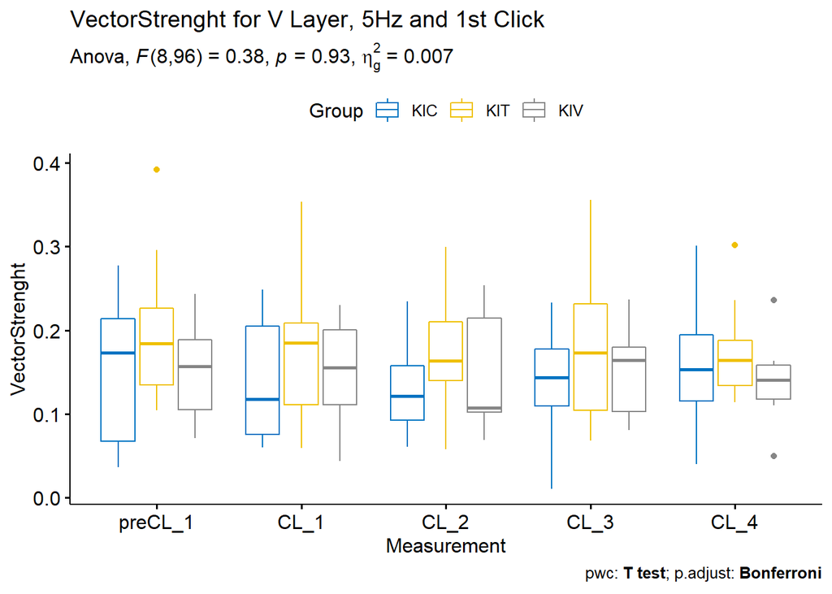

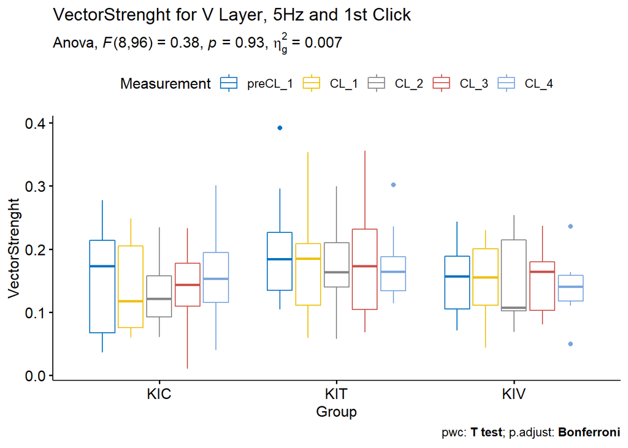

### VI Layer

#### VectorStrenght

##### Assumptions Check

**===OUTLIERS===**

| Group | Measurement | Animal | VectorStrenght | is.outlier | is.extreme |
| --- | --- | --- | --- | --- | --- |
| KIC | preCL_1 | KIC15 | 0.660830 | TRUE | TRUE |
| KIC | CL_1 | KIC15 | 0.771640 | TRUE | TRUE |
| KIV | CL_1 | KIV09 | 0.064437 | TRUE | FALSE |
| KIC | CL_2 | KIC15 | 0.770243 | TRUE | TRUE |
| KIC | CL_3 | KIC15 | 0.742225 | TRUE | TRUE |
| KIV | CL_3 | KIV04 | 0.226273 | TRUE | TRUE |
| KIV | CL_3 | KIV17 | 0.097969 | TRUE | FALSE |
| KIC | CL_4 | KIC15 | 0.858151 | TRUE | TRUE |

**===NORMALITY ASSUMPTION===**

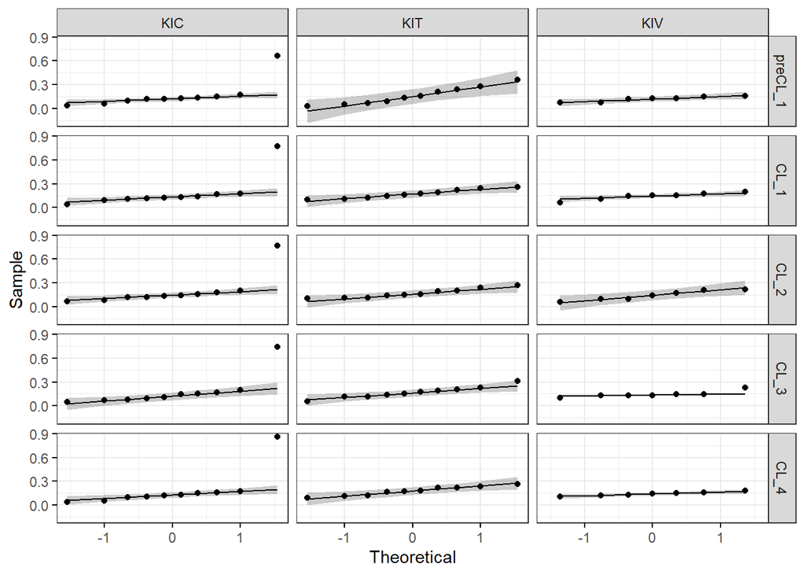

**===HOMOGENEITY OF VARIANCE ASSUMPTION===**

| Measurement | df1 | df2 | statistic | p |
| --- | --- | --- | --- | --- |
| preCL_1 | 2 | 24 | 0.812 | 0.456 |
| CL_1 | 2 | 24 | 0.623 | 0.545 |
| CL_2 | 2 | 24 | 0.493 | 0.617 |
| CL_3 | 2 | 24 | 1.016 | 0.377 |
| CL_4 | 2 | 24 | 0.898 | 0.420 |

##### Mixed ANOVA

| Effect | DFn | DFd | F | p | p..05 | ges |
| --- | --- | --- | --- | --- | --- | --- |
| Group | 2 | 24 | 0.259 | 0.774 |  | 0.020 |
| Measurement | 4 | 96 | 1.272 | 0.286 |  | 0.003 |
| Group:Measurement | 8 | 96 | 0.195 | 0.991 |  | 0.001 |

##### Post-hoc Tests

**===SIGNIFICANT TWO-WAY INTERACTION===**

**=EFFECT OF GROUP AT EACH MEASUREMENT=**

| Measurement | Effect | DFn | DFd | p | p..05 | ges | p.adj |
| --- | --- | --- | --- | --- | --- | --- | --- |
| preCL_1 | Group | 2 | 24 | 0.718 |  | 0.027 | 1 |
| CL_1 | Group | 2 | 24 | 0.808 |  | 0.018 | 1 |
| CL_2 | Group | 2 | 24 | 0.698 |  | 0.030 | 1 |
| CL_3 | Group | 2 | 24 | 0.852 |  | 0.013 | 1 |
| CL_4 | Group | 2 | 24 | 0.810 |  | 0.017 | 1 |

**=PAIRWISE COMPARISONS BETWEEN GROUP LEVELS=**

| Measurement | .y. | group1 | group2 | n1 | n2 | statistic | df | p | p.adj | p.adj.signif | effsize | magnitude |
| --- | --- | --- | --- | --- | --- | --- | --- | --- | --- | --- | --- | --- |
| preCL_1 | VectorStrenght | KIC | KIT | 10 | 10 | 0.078 | 15.041 | 0.939 | 1.000 | ns | 0.035 | negligible |
| preCL_1 | VectorStrenght | KIC | KIV | 10 | 7 | 0.845 | 9.975 | 0.418 | 1.000 | ns | 0.381 | small |
| preCL_1 | VectorStrenght | KIT | KIV | 10 | 7 | 1.170 | 11.411 | 0.266 | 0.798 | ns | 0.533 | moderate |
| CL_1 | VectorStrenght | KIC | KIT | 10 | 10 | 0.185 | 10.239 | 0.857 | 1.000 | ns | 0.083 | negligible |
| CL_1 | VectorStrenght | KIC | KIV | 10 | 7 | 0.630 | 10.166 | 0.543 | 1.000 | ns | 0.284 | small |
| CL_1 | VectorStrenght | KIT | KIV | 10 | 7 | 1.247 | 14.516 | 0.232 | 0.696 | ns | 0.604 | moderate |
| CL_2 | VectorStrenght | KIC | KIT | 10 | 10 | 0.437 | 10.393 | 0.671 | 1.000 | ns | 0.196 | negligible |
| CL_2 | VectorStrenght | KIC | KIV | 10 | 7 | 0.810 | 11.192 | 0.435 | 1.000 | ns | 0.369 | small |
| CL_2 | VectorStrenght | KIT | KIV | 10 | 7 | 0.895 | 12.415 | 0.388 | 1.000 | ns | 0.444 | small |
| CL_3 | VectorStrenght | KIC | KIT | 10 | 10 | 0.148 | 11.138 | 0.885 | 1.000 | ns | 0.066 | negligible |
| CL_3 | VectorStrenght | KIC | KIV | 10 | 7 | 0.557 | 9.960 | 0.590 | 1.000 | ns | 0.251 | small |
| CL_3 | VectorStrenght | KIT | KIV | 10 | 7 | 0.992 | 14.518 | 0.337 | 1.000 | ns | 0.466 | small |
| CL_4 | VectorStrenght | KIC | KIT | 10 | 10 | 0.128 | 10.042 | 0.901 | 1.000 | ns | 0.057 | negligible |
| CL_4 | VectorStrenght | KIC | KIV | 10 | 7 | 0.618 | 9.299 | 0.551 | 1.000 | ns | 0.277 | small |
| CL_4 | VectorStrenght | KIT | KIV | 10 | 7 | 1.798 | 13.266 | 0.095 | 0.285 | ns | 0.832 | large |

**=EFFECT OF MEASUREMENT AT EACH LEVEL OF GROUP=**

| Group | Effect | DFn | DFd | F | p | p..05 | ges | p.adj |
| --- | --- | --- | --- | --- | --- | --- | --- | --- |
| KIC | Measurement | 4 | 36 | 0.753 | 0.562 |  | 0.003 | 1 |
| KIT | Measurement | 4 | 36 | 0.233 | 0.918 |  | 0.006 | 1 |
| KIV | Measurement | 4 | 24 | 0.725 | 0.583 |  | 0.058 | 1 |

**=PAIRWISE COMPARISONS BETWEEN MEASUREMENTS AT EACH GROUP LEVELS=**

| Group | .y. | group1 | group2 | n1 | n2 | statistic | df | p | p.adj | p.adj.signif | effsize | magnitude |
| --- | --- | --- | --- | --- | --- | --- | --- | --- | --- | --- | --- | --- |
| KIC | VectorStrenght | preCL_1 | CL_1 | 10 | 10 | -1.419 | 9 | 0.190 | 1 | ns | -0.449 | small |
| KIC | VectorStrenght | preCL_1 | CL_2 | 10 | 10 | -1.766 | 9 | 0.111 | 1 | ns | -0.558 | moderate |
| KIC | VectorStrenght | preCL_1 | CL_3 | 10 | 10 | -0.676 | 9 | 0.516 | 1 | ns | -0.214 | small |
| KIC | VectorStrenght | preCL_1 | CL_4 | 10 | 10 | -0.892 | 9 | 0.395 | 1 | ns | -0.282 | small |
| KIC | VectorStrenght | CL_1 | CL_2 | 10 | 10 | -1.114 | 9 | 0.294 | 1 | ns | -0.352 | small |
| KIC | VectorStrenght | CL_1 | CL_3 | 10 | 10 | 0.375 | 9 | 0.717 | 1 | ns | 0.118 | negligible |
| KIC | VectorStrenght | CL_1 | CL_4 | 10 | 10 | -0.099 | 9 | 0.923 | 1 | ns | -0.031 | negligible |
| KIC | VectorStrenght | CL_2 | CL_3 | 10 | 10 | 1.129 | 9 | 0.288 | 1 | ns | 0.357 | small |
| KIC | VectorStrenght | CL_2 | CL_4 | 10 | 10 | 0.415 | 9 | 0.688 | 1 | ns | 0.131 | negligible |
| KIC | VectorStrenght | CL_3 | CL_4 | 10 | 10 | -0.302 | 9 | 0.769 | 1 | ns | -0.096 | negligible |
| KIT | VectorStrenght | preCL_1 | CL_1 | 10 | 10 | -0.498 | 9 | 0.630 | 1 | ns | -0.157 | negligible |
| KIT | VectorStrenght | preCL_1 | CL_2 | 10 | 10 | -0.329 | 9 | 0.749 | 1 | ns | -0.104 | negligible |
| KIT | VectorStrenght | preCL_1 | CL_3 | 10 | 10 | -0.420 | 9 | 0.685 | 1 | ns | -0.133 | negligible |
| KIT | VectorStrenght | preCL_1 | CL_4 | 10 | 10 | -0.676 | 9 | 0.516 | 1 | ns | -0.214 | small |
| KIT | VectorStrenght | CL_1 | CL_2 | 10 | 10 | 0.437 | 9 | 0.673 | 1 | ns | 0.138 | negligible |
| KIT | VectorStrenght | CL_1 | CL_3 | 10 | 10 | 0.193 | 9 | 0.851 | 1 | ns | 0.061 | negligible |
| KIT | VectorStrenght | CL_1 | CL_4 | 10 | 10 | -0.376 | 9 | 0.716 | 1 | ns | -0.119 | negligible |
| KIT | VectorStrenght | CL_2 | CL_3 | 10 | 10 | -0.163 | 9 | 0.874 | 1 | ns | -0.051 | negligible |
| KIT | VectorStrenght | CL_2 | CL_4 | 10 | 10 | -0.658 | 9 | 0.527 | 1 | ns | -0.208 | small |
| KIT | VectorStrenght | CL_3 | CL_4 | 10 | 10 | -0.518 | 9 | 0.617 | 1 | ns | -0.164 | negligible |
| KIV | VectorStrenght | preCL_1 | CL_1 | 7 | 7 | -1.633 | 6 | 0.154 | 1 | ns | -0.617 | moderate |
| KIV | VectorStrenght | preCL_1 | CL_2 | 7 | 7 | -0.949 | 6 | 0.379 | 1 | ns | -0.359 | small |
| KIV | VectorStrenght | preCL_1 | CL_3 | 7 | 7 | -1.699 | 6 | 0.140 | 1 | ns | -0.642 | moderate |
| KIV | VectorStrenght | preCL_1 | CL_4 | 7 | 7 | -1.754 | 6 | 0.130 | 1 | ns | -0.663 | moderate |
| KIV | VectorStrenght | CL_1 | CL_2 | 7 | 7 | 0.088 | 6 | 0.932 | 1 | ns | 0.033 | negligible |
| KIV | VectorStrenght | CL_1 | CL_3 | 7 | 7 | -0.056 | 6 | 0.957 | 1 | ns | -0.021 | negligible |
| KIV | VectorStrenght | CL_1 | CL_4 | 7 | 7 | 0.148 | 6 | 0.887 | 1 | ns | 0.056 | negligible |
| KIV | VectorStrenght | CL_2 | CL_3 | 7 | 7 | -0.107 | 6 | 0.918 | 1 | ns | -0.040 | negligible |
| KIV | VectorStrenght | CL_2 | CL_4 | 7 | 7 | 0.042 | 6 | 0.968 | 1 | ns | 0.016 | negligible |
| KIV | VectorStrenght | CL_3 | CL_4 | 7 | 7 | 0.294 | 6 | 0.779 | 1 | ns | 0.111 | negligible |

**===NON-SIGNIFICANT TWO-WAY INTERACTION===**

**=MAIN EFFECT OF MEASUREMENT=**

| .y. | group1 | group2 | n1 | n2 | statistic | df | p | p.adj | p.adj.signif |
| --- | --- | --- | --- | --- | --- | --- | --- | --- | --- |
| VectorStrenght | preCL_1 | CL_1 | 27 | 27 | -1.7070488 | 26 | 0.100 | 0.997 | ns |
| VectorStrenght | preCL_1 | CL_2 | 27 | 27 | -1.7441750 | 26 | 0.093 | 0.929 | ns |
| VectorStrenght | preCL_1 | CL_3 | 27 | 27 | -1.3354284 | 26 | 0.193 | 1.000 | ns |
| VectorStrenght | preCL_1 | CL_4 | 27 | 27 | -1.5784385 | 26 | 0.127 | 1.000 | ns |
| VectorStrenght | CL_1 | CL_2 | 27 | 27 | -0.2570414 | 26 | 0.799 | 1.000 | ns |
| VectorStrenght | CL_1 | CL_3 | 27 | 27 | 0.3179467 | 26 | 0.753 | 1.000 | ns |
| VectorStrenght | CL_1 | CL_4 | 27 | 27 | -0.1920139 | 26 | 0.849 | 1.000 | ns |
| VectorStrenght | CL_2 | CL_3 | 27 | 27 | 0.4580716 | 26 | 0.651 | 1.000 | ns |
| VectorStrenght | CL_2 | CL_4 | 27 | 27 | 0.0196846 | 26 | 0.984 | 1.000 | ns |
| VectorStrenght | CL_3 | CL_4 | 27 | 27 | -0.4287710 | 26 | 0.672 | 1.000 | ns |

**=MAIN EFFECT OF GROUP=**

| .y. | group1 | group2 | n1 | n2 | p | p.signif | p.adj | p.adj.signif |
| --- | --- | --- | --- | --- | --- | --- | --- | --- |
| VectorStrenght | KIC | KIT | 50 | 50 | 0.607 | ns | 1.000 | ns |
| VectorStrenght | KIC | KIV | 50 | 35 | 0.110 | ns | 0.330 | ns |
| VectorStrenght | KIT | KIV | 50 | 35 | 0.256 | ns | 0.767 | ns |

##### Plots

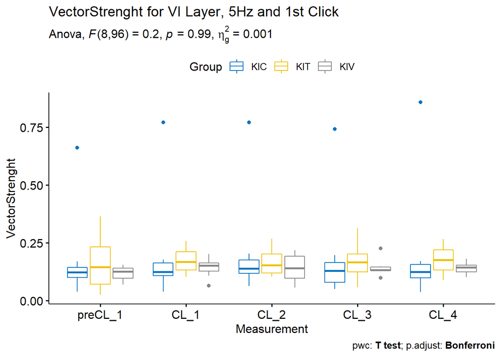

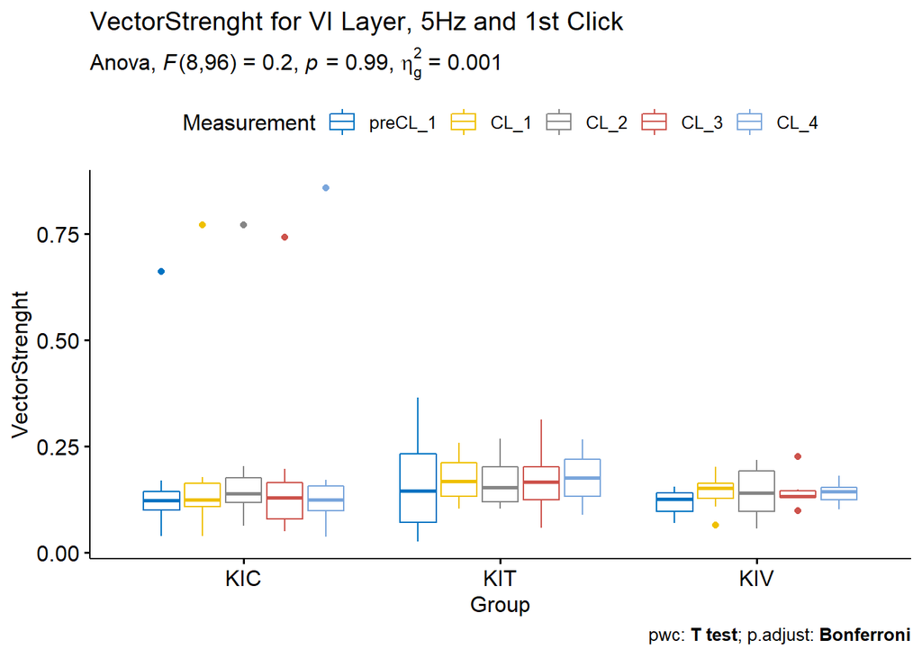